# Dynamic Pricing Engine: A ‘From Scratch’ Implementation

Abdullah Shahzad

2025-12-15

# Executive Summary

**Objective:** Build a white-box Dynamic Pricing engine to optimize revenue for Tropicana Orange Juice using the Dominick’s Finer Foods dataset.

**Methodology:**

- Manual MLE: Implemented Maximum Likelihood Estimation from scratch (bypassing lm) to estimate demand parameters.
- Multivariate Analysis: Controlled for competitor pricing (Minute Maid) to correct for Omitted Variable Bias.
- Revenue Optimization: Derived the optimal price point (P∗) using Calculus and the Optimal Markup Rule.

**Key Findings:**

- Price Elasticity: Corrected Own-Price Elasticity is -2.83 (High Sensitivity).
- Competitor Impact: Cross-Price Elasticity with Minute Maid is +0.49 (Strong Substitute).
- Recommendation: The product is currently underpriced. Increasing price to $0.062/oz is projected to increase weekly store profit by ~81%.

# Data Preparation

We filter the dataset for Tropicana Premium 64oz (Brand 1) and create log-transformed variables for elasticity modeling.

```r
# Load Data from bayesm package
data(orangeJuice)
oj_data <- orangeJuice$yx

# Filter for Brand 1 (Tropicana)
tropicana <- oj_data %>%
  filter(brand == 1) %>%
  mutate(log_price = log(price1),        # Own Price
         log_price_mm = log(price5))     # Competitor Price (Minute Maid)

# Quick Peek
head(tropicana %>% select(week, logmove, price1, price5, log_price, log_price_mm))
```

```
##   week  logmove     price1     price5 log_price log_price_mm
## 1   40 9.018695 0.06046875 0.04953125 -2.805629    -3.005151
## 2   46 8.723231 0.06046875 0.04953125 -2.805629    -3.005151
## 3   47 8.253228 0.06046875 0.03734375 -2.805629    -3.287590
## 4   48 8.987197 0.06046875 0.04953125 -2.805629    -3.005151
## 5   50 9.093357 0.06046875 0.04953125 -2.805629    -3.005151
## 6   51 8.877382 0.06046875 0.04953125 -2.805629    -3.005151
```

# Visualization (Univariate)

We visualize the demand curve. The downward slope confirms the “Law of Demand.”

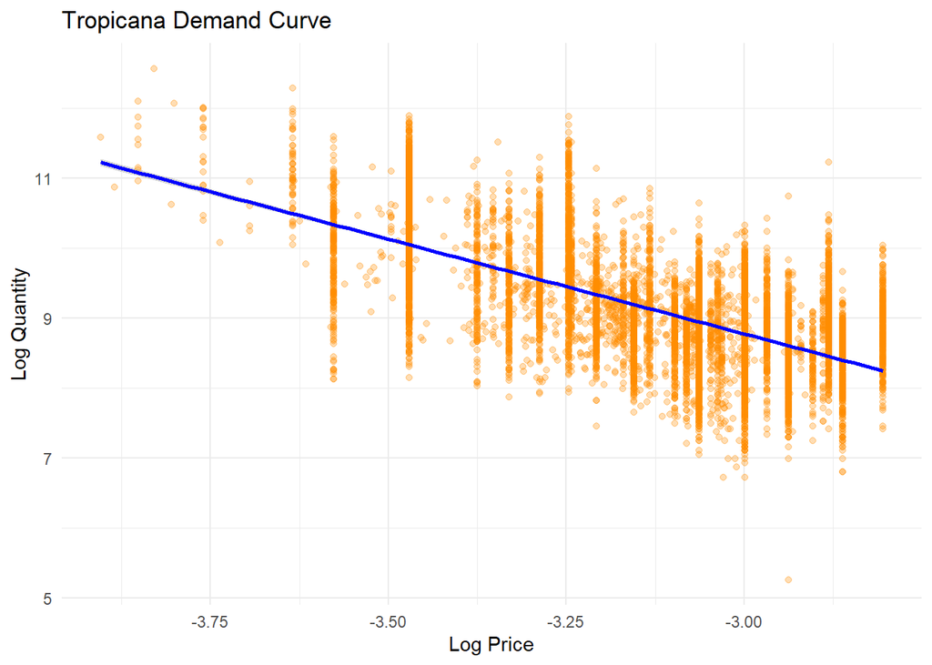

```r
ggplot(tropicana, aes(x = log_price, y = logmove)) +
  geom_point(alpha = 0.3, color = "darkorange") +
  geom_smooth(method = "lm", color = "blue") +
  labs(title = "Tropicana Demand Curve", x = "Log Price", y = "Log Quantity") +
  theme_minimal()
```

# Phase 1: The Univariate Engine

We start with a baseline model assuming demand depends only on our own price:
$$ln(Q)=β0+β1ln(P)+ϵ$$

## A. Manual Log-Likelihood Function

We define the function to calculate the probability of the data given parameters θ=[Intercept,Elasticity,σ].

```r
# Univariate Negative Log-Likelihood Function
nll_gaussian_simple <- function(theta, y, log_prices) {
  # Predicted Value
  y_hat <- theta[1] + theta[2] * log_prices

  # Probability Density of actual y
  # We return negative sum because optim minimizes
  sum_prob_y <- sum(dnorm(y, log = TRUE, mean = y_hat, sd = theta[3]))
  return(-sum_prob_y)
}
```

## B. Optimization (Univariate)

We use L-BFGS-B to find the parameters that maximize likelihood. We use benchmark values to initialize the optimizer to avoid local minima.

```r
# Benchmark Model for Initial Guesses
benchmark_model <- lm(logmove ~ log_price, tropicana)
theta_start_simple <- c(coef(benchmark_model)[1], coef(benchmark_model)[2], 1)

# Run Optimization
mle_results_simple <- optim(par = theta_start_simple,
                            fn = nll_gaussian_simple,
                            y = tropicana$logmove,
                            log_prices = tropicana$log_price,
                            method = "L-BFGS-B",
                            lower = c(-Inf, -Inf, 0.0001), # Sigma must be > 0
                            control = list(reltol = 1e-12, maxit = 10000))

# Result
print(mle_results_simple$par)
```

```
## (Intercept)   log_price
##   0.6394518  -2.7116655   0.6412137
```

## C. Standard Errors (Fisher Information)

We validate statistical significance by calculating Standard Errors using the Hessian Matrix.

```r
# Calculate Exact Hessian
hessian_mat <- hessian(func = nll_gaussian_simple,
                       x = mle_results_simple$par,
                       y = tropicana$logmove,
                       log_prices = tropicana$log_price)

# Invert to get Covariance Matrix and Standard Errors
fisher_info <- solve(hessian_mat)
std_errors <- sqrt(diag(fisher_info))

# Report
results_table_simple <- data.frame(
  Parameter = c("Intercept", "Price_Elasticity", "Sigma"),
  Estimate = mle_results_simple$par,
  Std_Error = std_errors
)
knitr::kable(results_table_simple, caption = "Univariate MLE Results")
```

Univariate MLE Results

|  | Parameter | Estimate | Std_Error |
| --- | --- | --- | --- |
| (Intercept) | Intercept | 0.6394518 | 0.1000530 |
| log_price | Price_Elasticity | -2.7116655 | 0.0319560 |
|  | Sigma | 0.6412137 | 0.0046158 |

## D. Initial Pricing Calculation

Based on this simple model, what would the optimal price be?

```r
# Inputs
marg_cost <- 0.04
beta_simple <- mle_results_simple$par[2]

# Optimal Price Formula (Univariate)
opt_price_simple <- marg_cost * (beta_simple / (1 + beta_simple))

cat(sprintf("Univariate Elasticity: %.3f\n", beta_simple))
```

```
## Univariate Elasticity: -2.712
```

```r
cat(sprintf("Initial Optimal Price: $%.3f\n", opt_price_simple))
```

```
## Initial Optimal Price: $0.063
```

**Initial Finding:** The univariate model suggests an elasticity of -2.71. Based on this, the initial Optimal Price is calculated as $0.063.

# Phase 2: The Multivariate Upgrade

We suspect Omitted Variable Bias. If Minute Maid changes prices at the same time as Tropicana, our simple model might be attributing that behavior incorrectly to our own price.

We upgrade the engine to:
$$ln(Q)=β0+β1ln(P~own~)+β2ln(P~comp~)+ϵ$$

## A. Cross-Elasticity Visualization

Plotting Competitor Price vs. Our Sales shows a confusing flat/downward trend. This suggests multicollinearity (prices moving together), confirming the need for multivariate regression to isolate the effects.

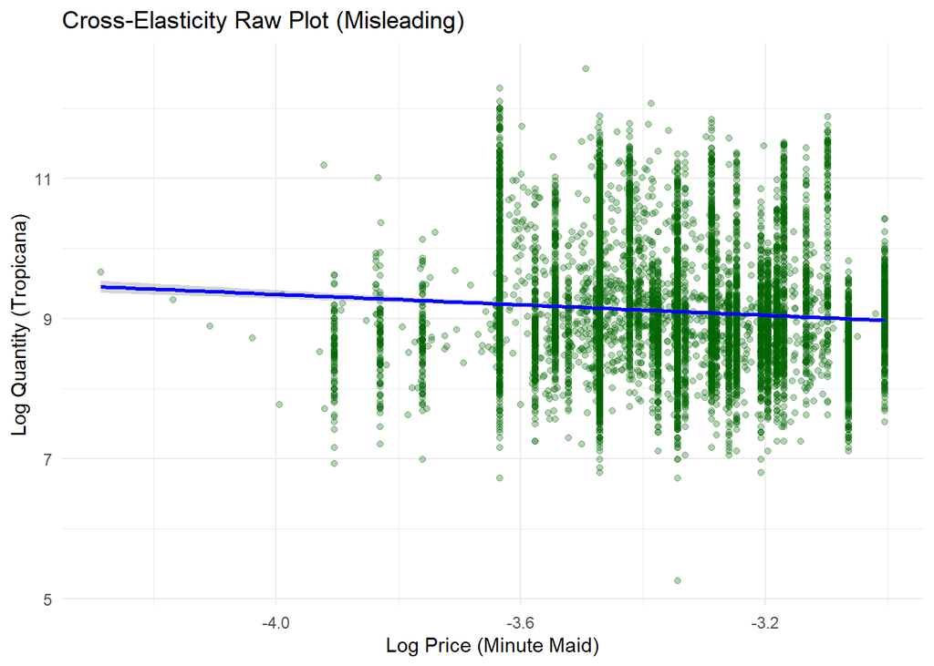

```r
ggplot(tropicana, aes(x = log_price_mm, y = logmove)) +
  geom_point(alpha = 0.3, color = "darkgreen") +
  geom_smooth(method = "lm", color = "blue") +
  labs(title = "Cross-Elasticity Raw Plot (Misleading)",
       x = "Log Price (Minute Maid)", y = "Log Quantity (Tropicana)") +
  theme_minimal()
```

## B. Multivariate Log-Likelihood

We add log_price_comp and a new parameter β2.

```r
# Multivariate Negative Log-Likelihood Function
nll_gaussian_multi <- function(theta, y, log_prices, log_price_comp) {
  # Predicted Value (Now includes Competitor Price)
  y_hat <- theta[1] + theta[2]*log_prices + theta[3]*log_price_comp

  # Probability Density
  sum_prob_y <- sum(dnorm(y, log = TRUE, mean = y_hat, sd = theta[4]))
  return(-sum_prob_y)
}
```

## C. Optimization (Multivariate)

```r
# Benchmark for starts
benchmark_model_comp <- lm(logmove ~ log_price + log_price_mm, data = tropicana)
theta_start_multi <- c(coef(benchmark_model_comp)[1],
                       coef(benchmark_model_comp)[2],
                       coef(benchmark_model_comp)[3],
                       1)

# Run Optimization
mult_mle_results <- optim(par = theta_start_multi,
                          fn = nll_gaussian_multi,
                          y = tropicana$logmove,
                          log_prices = tropicana$log_price,
                          log_price_comp = tropicana$log_price_mm,
                          method = "L-BFGS-B",
                          lower = c(-Inf, -Inf, -Inf, 0.0001),
                          control = list(reltol = 1e-12, maxit = 10000))

# Final Parameters
print(mult_mle_results$par)
```

```
##  (Intercept)    log_price log_price_mm
##    1.9314577   -2.8310056    0.4942883    0.6353866
```

# Key Insight: Omitted Variable Bias

Comparing the models reveals the “Cushion Effect.”

```r
comparison <- data.frame(
  Model = c("Univariate (Simple)", "Multivariate (Corrected)"),
  Own_Elasticity = c(round(mle_results_simple$par[2], 3), round(mult_mle_results$par[2], 3))
)
knitr::kable(comparison)
```

| Model | Own_Elasticity |
| --- | --- |
| Univariate (Simple) | -2.712 |
| Multivariate (Corrected) | -2.831 |

**Interpretation:**

- Simple Model (-2.71): Underestimated price sensitivity. It gave Tropicana credit for retaining customers when, in reality, Minute Maid was effectively “saving” Tropicana by also having high prices during those weeks.
- Multivariate Model (-2.83): Controlling for competition reveals that Tropicana customers are more sensitive than previously thought.
- Cross-Elasticity (+0.49): Confirms Minute Maid is a substitute.

# Final Recommendation & Business Impact

**The Corrected Optimal Price**

Using the corrected elasticity (β=−2.83), we solve for the profit-maximizing price:

$$P^{*} = \text{Cost} \times
\frac{\beta}{1 + \beta}$$

```r
# Inputs
marg_cost <- 0.04
beta_final <- mult_mle_results$par[2]

# Optimal Price Calculation
opt_price_mult <- marg_cost * (beta_final / (1 + beta_final))
curr_price <- mean(tropicana$price1)

# Report Prices
cat(sprintf("Current Avg Price:   $%.3f\n", curr_price))
```

```
## Current Avg Price:   $0.045
```

```r
cat(sprintf("Final Optimal Price: $%.3f\n", opt_price_mult))
```

```
## Final Optimal Price: $0.062
```

## Projected Change in Quantity Sold & Profit

```r
# 1. Extract All Parameters
b0 <- mult_mle_results$par[1]  # Intercept
b1 <- mult_mle_results$par[2]  # Own Elasticity
b2 <- mult_mle_results$par[3]  # Cross-Elasticity (Competitor)
cost <- 0.04

# 2. Define Prices
p_own_current <- mean(tropicana$price1)
p_own_optimal <- opt_price_mult       # From previous chunk
p_comp_avg    <- mean(tropicana$price5) # Hold Competitor Price Constant at Avg

# 3. Predict Quantity (Multivariate Prediction)
# Q = exp(b0) * (P_own)^b1 * (P_comp)^b2
q_current <- exp(b0) * (p_own_current^b1) * (p_comp_avg^b2)
q_optimal <- exp(b0) * (p_own_optimal^b1) * (p_comp_avg^b2)

# 4. Calculate Profit
profit_current <- (p_own_current - cost) * q_current
profit_optimal <- (p_own_optimal - cost) * q_optimal

# Create a summary table for the final report
impact_table <- data.frame(
  Metric = c("Price ($/oz)", "Volume (Units)", "Weekly Profit"),
  Current = c(p_own_current, q_current, profit_current),
  Optimal = c(p_own_optimal, q_optimal, profit_optimal)
)

# Calculate % Change column
impact_table$Change_Pct <- (impact_table$Optimal - impact_table$Current) / impact_table$Current * 100

# Formatting for display
impact_table$Current <- round(impact_table$Current, 2)
impact_table$Optimal <- round(impact_table$Optimal, 2)
impact_table$Change_Pct <- paste0(round(impact_table$Change_Pct, 1), "%")

# Print nice table
knitr::kable(impact_table, caption = "Projected Business Impact (Weekly Per Store)")
```

Projected Business Impact (Weekly Per Store)

| Metric | Current | Optimal | Change_Pct |
| --- | --- | --- | --- |
| Price ($/oz) | 0.04 | 0.06 | 37.9% |
| Volume (Units) | 8632.09 | 3476.07 | -59.7% |
| Weekly Profit | 41.88 | 75.94 | 81.3% |

# Conclusion

The analysis recommends increasing the price to $0.062. While this strategy accepts a lower sales volume (due to high elasticity), the substantial increase in margin per unit drives a projected 81% increase in weekly profitability.